# Snappet Data Challenge Notebook

Bram Zandbelt

# 1 Overview

This notebook describes a set of data processing, analysis, and visualization steps of a Snappet dataset. The ultimate result of this analysis is a set of visualizations that provide an overview of a classroom’s activity on March 24th 2015 at 11:30 AM, describing *what* pupils have worked and *how* they have worked. With these visualizations, I intended to provide (deep) insight without being overwhelming.

# 2 Preliminaries

```r
# Much of the data reading, cleaning, processing, and plotting is done with packages from the tidyverse package collection; loading this packacke is required to have access to the %>%-operator
library(tidyverse)
```

# 3 Read data

```r
raw_data_dir <- file.path("../Data")
raw_data_filename <- list.files(path = raw_data_dir,
                                pattern = "^work.csv$")

raw_data <-
  readr::read_csv(file = file.path(raw_data_dir, raw_data_filename),
                  col_types = readr::cols()
                  )
```

# 4 Clean data

## 4.1 Inspect the data

Let’s look at first and last lines to get an idea of the dataset.

First lines:

```r
head(raw_data, n = 10)
```

| SubmittedAnswerId | SubmitDateTime | Correct | Progress | UserId | ExerciseId | Difficulty | Subject | Domain | LearningObjective |
| --- | --- | --- | --- | --- | --- | --- | --- | --- | --- |
| 2395278 | 2015-03-02 07:35:38 | 1 | 0 | 40281 | 1038396 | -200 | Begrijpend Lezen | - | Diverse leerdoelen Begrijpend Lezen |
| 2396494 | 2015-03-02 07:36:48 | 1 | 2 | 40281 | 1029120 | 329.2341931 | Begrijpend Lezen | - | Diverse leerdoelen Begrijpend Lezen |
| 2396638 | 2015-03-02 07:36:55 | 1 | 0 | 40282 | 1013670 | -200 | Begrijpend Lezen | - | Diverse leerdoelen Begrijpend Lezen |
| 2396696 | 2015-03-02 07:36:59 | 1 | 2 | 40281 | 1029121 | 353.3972855 | Begrijpend Lezen | - | Diverse leerdoelen Begrijpend Lezen |
| 2397209 | 2015-03-02 07:37:24 | 1 | 0 | 40285 | 1038506 | -200 | Begrijpend Lezen | - | Diverse leerdoelen Begrijpend Lezen |
| 2397600 | 2015-03-02 07:37:43 | 0 | -10 | 40285 | 1038509 | 230.6971675 | Begrijpend Lezen | - | Diverse leerdoelen Begrijpend Lezen |
| 2397725 | 2015-03-02 07:37:48 | 1 | 0 | 40285 | 1038509 | 230.6971675 | Begrijpend Lezen | - | Diverse leerdoelen Begrijpend Lezen |
| 2397740 | 2015-03-02 07:37:49 | 1 | 2 | 40282 | 1013691 | 323.9532905 | Begrijpend Lezen | - | Diverse leerdoelen Begrijpend Lezen |
| 2397893 | 2015-03-02 07:37:56 | 1 | 0 | 40282 | 1013695 | 191.9839136 | Begrijpend Lezen | - | Diverse leerdoelen Begrijpend Lezen |
| 2398069 | 2015-03-02 07:38:05 | 1 | 4 | 40282 | 1013698 | 417.5709591 | Begrijpend Lezen | - | Diverse leerdoelen Begrijpend Lezen |

Last lines:

```r
tail(raw_data, n = 10)
```

| SubmittedAnswerId | SubmitDateTime | Correct | Progress | UserId | ExerciseId | Difficulty | Subject | Domain | LearningObjective |
| --- | --- | --- | --- | --- | --- | --- | --- | --- | --- |
| 84531178 | 2015-03-30 10:49:48 | 1 | 3 | 40284 | 133470 | 197.5915864 | Spelling | Taalverzorging | woorden met twee verschillende medeklinkers in het midden (kasteel, zakdoek) |
| 84531261 | 2015-03-30 10:49:50 | 1 | 4 | 40274 | 185980 | 337.986709 | Spelling | Taalverzorging | woorden met twee verschillende medeklinkers in het midden (kasteel, zakdoek) |
| 84531280 | 2015-03-30 10:49:51 | 0 | 0 | 40268 | 386086 | 269.2496919 | Spelling | Taalverzorging | woorden met twee verschillende medeklinkers in het midden (kasteel, zakdoek) |
| 84531437 | 2015-03-30 10:49:54 | 1 | 0 | 40272 | 439990 | 245.9474273 | Spelling | Taalverzorging | woorden met twee verschillende medeklinkers in het midden (kasteel, zakdoek) |
| 84531617 | 2015-03-30 10:49:57 | 1 | 0 | 40281 | 403784 | 260.1732307 | Spelling | Taalverzorging | woorden met twee verschillende medeklinkers in het midden (kasteel, zakdoek) |
| 84531500 | 2015-03-30 10:49:59 | 0 | 0 | 40277 | 350089 | 236.453563 | Spelling | Taalverzorging | woorden met twee verschillende medeklinkers in het midden (kasteel, zakdoek) |
| 84531648 | 2015-03-30 10:49:59 | 1 | 3 | 68421 | 480757 | 271.0945566 | Spelling | Taalverzorging | woorden met twee verschillende medeklinkers in het midden (kasteel, zakdoek) |
| 84531788 | 2015-03-30 10:50:01 | 1 | 4 | 40274 | 357219 | 341.8771423 | Spelling | Taalverzorging | woorden met twee verschillende medeklinkers in het midden (kasteel, zakdoek) |
| 84531853 | 2015-03-30 10:50:02 | 0 | -7 | 40285 | 439719 | 310.6629381 | Spelling | Taalverzorging | woorden met twee verschillende medeklinkers in het midden (kasteel, zakdoek) |
| 84532297 | 2015-03-30 10:50:15 | 1 | 3 | 40273 | 34636 | 333.9262981 | Spelling | Taalverzorging | woorden met twee verschillende medeklinkers in het midden (kasteel, zakdoek) |

Now, get some descriptive statistics on the raw data to identify potential problems. Note that the output of summarytools::dfSummary doesn’t render well to HTML; it is best viewed by running the notebook interactively.

```r
print(summarytools::dfSummary(raw_data, max.distinct.values = 100))
```

```
## Data Frame Summary
##
## Dimensions: 37812 x 10
## Duplicates: 0
##
## ----------------------------------------------------------------------------------------------------------------------------------------------
## No   Variable             Stats / Values                         Freqs (% of Valid)      Graph                              Valid    Missing
## ---- -------------------- -------------------------------------- ----------------------- ---------------------------------- -------- ---------
## 1    SubmittedAnswerId    Mean (sd) : 45224900.4 (23454427.6)    37812 distinct values         :         :                  37812    0
##      [integer]            min < med < max:                                                     :         :                  (100%)   (0%)
##                           2395278 < 40956148.5 < 84532297                                . : : : :   : : : :
##                           IQR (CV) : 40850114.2 (0.5)                                    : : : : : . : : : :
##                                                                                          : : : : : : : : : :
##
## 2    SubmitDateTime       min : 2015-03-02 07:35:38              29796 distinct values         :                            37812    0
##      [POSIXct, POSIXt]    med : 2015-03-13 10:52:51                                          . :       . :                  (100%)   (0%)
##                           max : 2015-03-30 10:50:15                                      . . : :       : :
##                           range : 28d 3H 14M 37.08S                                      : : : :   : : : : .
##                                                                                          : : : :   : : : : :
##
## 3    Correct              Mean (sd) : 0.8 (0.4)                  0 :  7984 (21.1%)       IIII                               37812    0
##      [integer]            min < med < max:                       1 : 29641 (78.4%)       IIIIIIIIIIIIIII                    (100%)   (0%)
##                           0 < 1 < 3                              3 :   187 ( 0.5%)
##                           IQR (CV) : 0 (0.5)
##
## 4    Progress             Mean (sd) : 0.3 (8.7)                  165 distinct values                 :                      37812    0
##      [integer]            min < med < max:                                                           :                      (100%)   (0%)
##                           -153 < 0 < 91                                                              :
##                           IQR (CV) : 3 (32.2)                                                        :
##                                                                                                    . :
##
## 5    UserId               Mean (sd) : 42013.3 (6771.9)           40267 : 2412 (6.4%)     I                                  37812    0
##      [integer]            min < med < max:                       40268 : 1758 (4.7%)                                        (100%)   (0%)
##                           40267 < 40277 < 68421                  40270 : 1812 (4.8%)
##                           IQR (CV) : 11 (0.2)                    40271 : 2099 (5.5%)     I
##                                                                  40272 : 1542 (4.1%)
##                                                                  40273 : 1871 (5.0%)
##                                                                  40274 : 2037 (5.4%)     I
##                                                                  40275 : 1972 (5.2%)     I
##                                                                  40276 : 2408 (6.4%)     I
```

[output cut: 196 more lines]

```
##                           66. woorden eindigend op -d o          3147 ( 8.3%)            I
##                           67. woorden met -a, -o, -u (p             3 ( 0.0%)
##                           68. woorden met -aai, -ooi, -            17 ( 0.0%)
##                           69. woorden met -ch(t) (pech,           837 ( 2.2%)
##                           70. woorden met -eer, -oor, -            42 ( 0.1%)
##                           71. woorden met -eeuw/-ieuw/-             9 ( 0.0%)
##                           72. woorden met -nk of ng (ba             2 ( 0.0%)
##                           73. woorden met -ou-, -ouw, -           840 ( 2.2%)
##                           74. woorden met (-)ei(-) of (            24 ( 0.1%)
##                           75. woorden met een tweeteken            35 ( 0.1%)
##                           76. woorden met mm kmm (plant            16 ( 0.0%)
##                           77. woorden met twee verschil          5693 (15.1%)            III
##                           78. woorden met uitgang -el,              6 ( 0.0%)
##                           79. woorden met uitgang -lijk            14 ( 0.0%)
## ----------------------------------------------------------------------------------------------------------------------------------------------
```

## 4.2 Clean the data

```r
tidy_data <-
  raw_data %>%

  # Unite Subject and Domain columns to reduce complexity
  tidyr::unite(col = "SubjectDomain", Subject, Domain) %>%
  dplyr::filter(Correct <= 1) %>%
  dplyr::mutate(
    # One LearningObjective level caused problems later in the analysis because of a non-recognized character
    LearningObjective = str_replace(string = LearningObjective,
                                    pattern = "Optellen en aftrekken tot \xb11000",
                                    replacement = "Optellen en aftrekken tot 10000" ),
    # Identify missing data
    Difficulty = readr::parse_double(Difficulty, na = c("NULL", "", "NA")),
    # Convert several variables into factors for plotting purposes
    UserId = factor(UserId, ordered = TRUE),
    ExerciseId = factor(ExerciseId, ordered = TRUE),
    SubjectDomain = factor(SubjectDomain, ordered = FALSE),
    LearningObjective = factor(LearningObjective, ordered = FALSE)
    )
```

Inspect the data again, to see if problems are solved

```r
print(summarytools::dfSummary(tidy_data, max.distinct.values = 100))
```

```
## Data Frame Summary
##
## Dimensions: 37625 x 9
## Duplicates: 0
##
## ------------------------------------------------------------------------------------------------------------------------------------------------
## No   Variable             Stats / Values                         Freqs (% of Valid)      Graph                              Valid      Missing
## ---- -------------------- -------------------------------------- ----------------------- ---------------------------------- ---------- ---------
## 1    SubmittedAnswerId    Mean (sd) : 45113530.5 (23398859.8)    37625 distinct values         :         :                  37625      0
##      [integer]            min < med < max:                                                     :         :                  (100%)     (0%)
##                           2395278 < 40948133 < 84532297                                  . : : : :   : : : :
##                           IQR (CV) : 40772098 (0.5)                                      : : : : : . : : : :
##                                                                                          : : : : : : : : : :
##
## 2    SubmitDateTime       min : 2015-03-02 07:35:38              29664 distinct values         :                            37625      0
##      [POSIXct, POSIXt]    med : 2015-03-13 10:51:59                                          . :       . :                  (100%)     (0%)
##                           max : 2015-03-30 10:50:15                                      . . : :       : :
##                           range : 28d 3H 14M 37.08S                                      : : : :   : : : : .
##                                                                                          : : : :   : : : : :
##
## 3    Correct              Min  : 0                               0 :  7984 (21.2%)       IIII                               37625      0
##      [integer]            Mean : 0.8                             1 : 29641 (78.8%)       IIIIIIIIIIIIIII                    (100%)     (0%)
##                           Max  : 1
##
## 4    Progress             Mean (sd) : 0.3 (8.7)                  165 distinct values                 :                      37625      0
##      [integer]            min < med < max:                                                           :                      (100%)     (0%)
##                           -153 < 0 < 91                                                              :
##                           IQR (CV) : 3 (32.1)                                                        :
##                                                                                                    . :
##
## 5    UserId               1. 40267                               2399 (6.4%)             I                                  37625      0
##      [ordered, factor]    2. 40268                               1736 (4.6%)                                                (100%)     (0%)
##                           3. 40270                               1806 (4.8%)
##                           4. 40271                               2085 (5.5%)             I
##                           5. 40272                               1529 (4.1%)
##                           6. 40273                               1865 (5.0%)
##                           7. 40274                               2030 (5.4%)             I
##                           8. 40275                               1966 (5.2%)             I
##                           9. 40276                               2394 (6.4%)             I
##                           10. 40277                              1678 (4.5%)
```

[output cut: 191 more lines]

```
##                           65. woorden eindigend op -d o          3147 ( 8.4%)            I
##                           66. woorden met -a, -o, -u (p             3 ( 0.0%)
##                           67. woorden met -aai, -ooi, -            17 ( 0.1%)
##                           68. woorden met -ch(t) (pech,           837 ( 2.2%)
##                           69. woorden met -eer, -oor, -            42 ( 0.1%)
##                           70. woorden met -eeuw/-ieuw/-             9 ( 0.0%)
##                           71. woorden met -nk of ng (ba             2 ( 0.0%)
##                           72. woorden met -ou-, -ouw, -           840 ( 2.2%)
##                           73. woorden met (-)ei(-) of (            24 ( 0.1%)
##                           74. woorden met een tweeteken            35 ( 0.1%)
##                           75. woorden met mm kmm (plant            16 ( 0.0%)
##                           76. woorden met twee verschil          5693 (15.1%)            III
##                           77. woorden met uitgang -el,              6 ( 0.0%)
##                           78. woorden met uitgang -lijk            14 ( 0.0%)
## ------------------------------------------------------------------------------------------------------------------------------------------------
```

Looking good now

## 4.3 Filter records, restricting analysis to today’s data up to 11:30 UTC

```r
# Today's data
today_data <-
  tidy_data %>%
  # Restrict analysis to today's data until 11:30 UTC, in line with assignment
  dplyr::filter(SubmitDateTime > "2015-03-24 00:00:00",
                SubmitDateTime <= "2015-03-24 11:30:00")  %>%
  # Focus analysis on the learning objectives that have been most worked on, categorize remainder as "Other"
  dplyr::mutate(LearningObjectiveFrequent =
                  forcats::fct_lump(f = .$LearningObjective, prop = .05) %>%
                  forcats::fct_infreq() %>%
                  forcats::fct_rev()
                )

# Group and nest data according to SubjectDomain and LearningObjective for further processing
today_data_nested <-
  today_data %>%
  dplyr::group_by(SubjectDomain, LearningObjective) %>%
  tidyr::nest() %>%
  dplyr::mutate(n_exercise = purrr::pmap_int(.l = list(x = .$data),
                                             .f = function(x) {nrow(x)})
                )
```

One more time some descriptive statistics, now of the dataset that is to be analyzed. This gives an impression of the number of data points in the analysis.

```r
print(summarytools::dfSummary(today_data))
```

```
## Data Frame Summary
##
## Dimensions: 1717 x 10
## Duplicates: 0
##
## ---------------------------------------------------------------------------------------------------------------------------------------------------
## No   Variable                     Stats / Values                       Freqs (% of Valid)     Graph                            Valid      Missing
## ---- ---------------------------- ------------------------------------ ---------------------- -------------------------------- ---------- ---------
## 1    SubmittedAnswerId            Mean (sd) : 66759327.6 (755855.7)    1717 distinct values             :                      1717       0
##      [integer]                    min < med < max:                                            . . :     :                      (100%)     (0%)
##                                   65601797 < 66635382 < 68795522                              : : : : : :
##                                   IQR (CV) : 1134260 (0)                                      : : : : : :
##                                                                                               : : : : : : .   . :
##
## 2    SubmitDateTime               min : 2015-03-24 07:33:41            1425 distinct values           :                        1717       0
##      [POSIXct, POSIXt]            med : 2015-03-24 08:30:45                                       . . :                        (100%)     (0%)
##                                   max : 2015-03-24 10:28:11                                       : : :
##                                   range : 2H 54M 29.78S                                         . : : :
##                                                                                               : : : : :         :
##
## 3    Correct                      Min  : 0                             0 :  360 (21.0%)       IIII                             1717       0
##      [integer]                    Mean : 0.8                           1 : 1357 (79.0%)       IIIIIIIIIIIIIII                  (100%)     (0%)
##                                   Max  : 1
##
## 4    Progress                     Mean (sd) : 0.3 (3.9)                34 distinct values                   :                  1717       0
##      [integer]                    min < med < max:                                                          :                  (100%)     (0%)
##                                   -37 < 0 < 14                                                              :
##                                   IQR (CV) : 3 (13.3)                                                       :
##                                                                                                         . . : :
##
## 5    UserId                       1. 40267                              76 ( 4.4%)                                             1717       0
##      [ordered, factor]            2. 40268                              79 ( 4.6%)                                             (100%)     (0%)
##                                   3. 40270                              82 ( 4.8%)
##                                   4. 40271                             133 ( 7.7%)            I
##                                   5. 40272                              31 ( 1.8%)
##                                   6. 40273                              74 ( 4.3%)
##                                   7. 40274                              98 ( 5.7%)            I
##                                   8. 40275                             152 ( 8.9%)            I
##                                   9. 40276                             160 ( 9.3%)            I
##                                   10. 40277                             64 ( 3.7%)
```

[output cut: 32 more lines]

```
##                                   5. Diverse leerdoelen Begrij           94 ( 5.5%)           I
##                                   6. Gehele getallen plaatsen           240 (14.0%)           II
##                                   7. Gehele getallen: vergelij            0 ( 0.0%)
##                                   8. Getallenrij                          0 ( 0.0%)
##                                   9. Handig rekenen - Met een             4 ( 0.2%)
##                                   10. Handig rekenen - Optellen           0 ( 0.0%)
##                                   [ 68 others ]                        1379 (80.3%)           IIIIIIIIIIIIIIII
##
## 10   LearningObjectiveFrequent    1. Diverse leerdoelen Begrij          94 ( 5.5%)            I                                1717       0
##      [factor]                     2. Inzicht in relatie 3D en          153 ( 8.9%)            I                                (100%)     (0%)
##                                   3. Gehele getallen plaatsen          240 (14.0%)            II
##                                   4. Other                             344 (20.0%)            IIII
##                                   5. Vermenigvuldigen 8 x 32           404 (23.5%)            IIII
##                                   6. Optellen en aftrekken tot         482 (28.1%)            IIIII
## ---------------------------------------------------------------------------------------------------------------------------------------------------
```

# 5 Analyze and visualize data

## 5.1 What did pupils do today?

This visualization shows the learning objectives that pupils worked on. The left panel shows when (horizontal axis) exercises were performed by each pupil (vertical axis); each vertical marker is one exercise. The right panel shows the total number of exercises that were completed (horizontal axis) by each pupil (vertical axis). In both panels, pupils are ordered based on the total number of exercises they completed (most productive pupils on top). Color indicates the learning objective (only the most frequent learning objectives are shown, remaining objectives are categorized as “Other”).

```r
plot_productivity <- function(tibb) {

  # Filter and compute relevant the data =======================================

  # Compute the number of exercises performed per learning objective
  summary_today_n_exercise_user_objective <-
    tibb %>%
    tidyr::unnest() %>%
    dplyr::group_by(UserId, LearningObjectiveFrequent) %>%
    dplyr::summarize(n_exercise = n())

  # Compute the number of exercises performed across all learning objectives
  summary_today_n_exercise_user <-
    tibb %>%
      tidyr::unnest() %>%
      dplyr::group_by(UserId) %>%
      dplyr::summarize(n_total = n())

  # Join these summary datasets on UserId
  summary_today_n_exercise <-
    dplyr::left_join(summary_today_n_exercise_user_objective,
                     summary_today_n_exercise_user,
                     by = c("UserId"))

  # Join summary datasets with input data
  productivity_data <-
    tibb %>%
      tidyr::unnest() %>%
      dplyr::left_join(summary_today_n_exercise,
                       by = c("UserId", "LearningObjectiveFrequent"))

  # Plot productivity in terms of which exercises are performed when ===========
  plt_left <-

    # General design -----------------------------------------------------------
    ggplot2::ggplot(data = productivity_data,
                    mapping = ggplot2::aes(x = forcats::fct_reorder(UserId, n_total),
                                           y = SubmitDateTime,
                                           color = LearningObjectiveFrequent)) +

    # Geoms --------------------------------------------------------------------
    # User vertical marker to get impression of density
    ggplot2::geom_point(shape = 124) +

    # Scales -------------------------------------------------------------------
    ggplot2::scale_x_discrete(name = "User Id (ordered by number of exercises)") +
    ggplot2::scale_y_datetime(name = "Clock Time (UTC)") +
    ggplot2::coord_flip() +
    ggplot2::theme_minimal()

  # Plot productivity in terms of total number of exercises completed ==========
  plt_right <-

    # General design -----------------------------------------------------------
    ggplot2::ggplot(data = summary_today_n_exercise,
                  mapping = ggplot2::aes(x = forcats::fct_reorder(UserId, n_total),
                                         y = n_exercise,
                                         fill = LearningObjectiveFrequent)) +
    # Geoms --------------------------------------------------------------------
    ggplot2::geom_bar(stat = "identity") +

    # Scales -------------------------------------------------------------------
    ggplot2::scale_x_discrete(name = "User Id") +
    ggplot2::scale_y_continuous(name = "Number of exercises") +
    ggplot2::coord_flip() +

    # Theme ---------------------------------------------------------------------
    ggplot2::theme_minimal() +
    # # User Id axis title and text are redundant
    ggplot2::theme(axis.title.y = ggplot2::element_blank(),
                   axis.text.y = ggplot2::element_blank())

  # Merge plt_left and plt_right and add common legend below ===================
  lgnd <- cowplot::get_legend(plt_right + ggplot2::theme(legend.position = "bottom",
                                                         legend.direction = "horizontal",
                                                         legend.box = "vertical",
                                                         legend.title = ggplot2::element_blank()))

  plt_top <-
    cowplot::plot_grid(plt_left + ggplot2::theme(legend.position = "none"),
                       plt_right + ggplot2::theme(legend.position = "none"),
                       nrow = 1)
  cowplot::plot_grid(plt_top,
                       lgnd,
                       nrow = 2,
                       rel_heights = c(0.9,0.2))
}
```

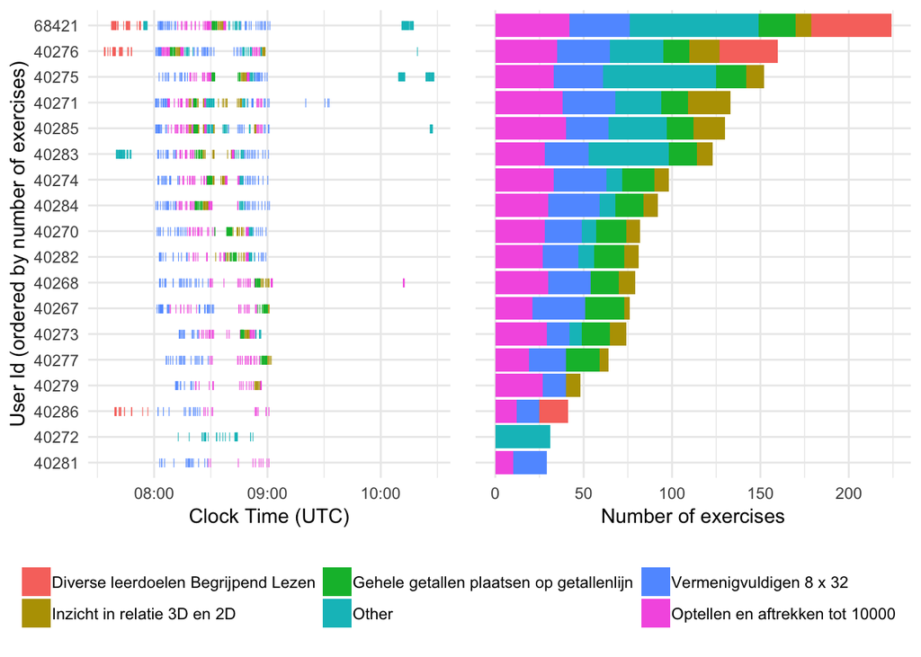

```r
plot_productivity(tibb = today_data_nested)
```

*How could this visualization help teachers?*

This visualization may help the teacher:

- get an overview of what all pupils have worked on and when
- identify pupils who are more and less productive

## 5.2 How did pupils perform?

The following visualizations show an overview of performance for a given learning objective (here: “Vermenigvuldigen 8 x 32”; This can be changed by altering the `learning_objective` argument of the plot functions). I made two sets of visualizations, one providing an overview of performance based on accuracy (percentage correct), the other providing an overview of performance based on change in exercise difficulty.

### 5.2.1 How did pupils perform in terms of accuracy?

This visualization provides an overview of pupil performance in terms of accuracy (i.e. percentage correct responses). The left panel shows the percentage of correct exercises (horizontal axis) for each pupil (vertical axis). The dashed line indicates the class’s median performance. Bar color indicates whether the pupil performance above (green) or below (red) class’s median performance. The right panel shows performance on each individual exercise corresponding to this learning goal (horizontal axis) for each pupil (vertical axis). Each pie chart is an exercise; color indicate the proportion of correct (blue) and incorrect (responses). In both panels, pupils are ordered based on their performance (best performance on top).

```r
plot_performance_accuracy <- function(tibb, learning_objective) {

  learning_objective_data <-
    tibb %>%
    dplyr::filter(LearningObjective == learning_objective) %>%
    dplyr::select(data) %>%
    tidyr::unnest()
  learning_objective_data <-
    learning_objective_data %>%
    dplyr::mutate(UserId = forcats::fct_drop(learning_objective_data$UserId))

  # Compute performance wrt to peers (i.e. class median performance) ===========
  performance_wrt_peers <-
    learning_objective_data %>%
    dplyr::mutate(UserId = droplevels(UserId)) %>%
    dplyr::group_by(UserId) %>%
    dplyr::summarize(user_accuracy = mean(Correct)) %>%
    dplyr::ungroup() %>%
    dplyr::mutate(rel_accuracy = user_accuracy - median(user_accuracy),
                  rel_accuracy_type = ifelse(rel_accuracy < 0, "below", "above")) %>%
    dplyr::mutate(UserId = forcats::fct_reorder(UserId, user_accuracy)) %>%
    dplyr::arrange(UserId)

  user_id_factor <- performance_wrt_peers$UserId

  # Compute performance wrt to ExerciseId ======================================
  performance_wrt_exerciseid <-
    learning_objective_data %>%
    # Only keep exercises that were performed today
    dplyr::mutate(ExerciseId = droplevels(ExerciseId)) %>%

    # Compute accuracy per exercise per pupil
    dplyr::group_by(UserId, ExerciseId) %>%
    dplyr::summarise(t_first_attempt = dplyr::first(SubmitDateTime),
                     correct = mean(Correct),
                     incorrect = 1 - correct) %>%
    dplyr::ungroup() %>%
    # Compute exercise index
    dplyr::group_by(UserId) %>%
    dplyr::arrange(t_first_attempt) %>%
    dplyr::mutate(ExerciseIx = 1:n()) %>%
    dplyr::ungroup() %>%

    # Re-order pupils based on accuracy
    dplyr::mutate(UserId = forcats::fct_relevel(UserId, levels(user_id_factor)))  %>%
    dplyr::mutate(UserIdInt = as.integer(UserId)) %>%
    dplyr::arrange(UserIdInt)

  # Plot performance wrt to peers ==============================================

  # Make y-axis labels (N.B. coords will be flipped)
  plot_ylimits <- c(0,1) - median(performance_wrt_peers$user_accuracy)
  plot_ybreaks <- seq(0.1, 0.9, 0.2) - median(performance_wrt_peers$user_accuracy)
  plot_ylabels <- stringr::str_c(seq(0.1, 0.9, 0.2) * 100, "%")

  plt_performance_wrt_peers <-

    # General design -----------------------------------------------------------
    ggplot(data = performance_wrt_peers,
           mapping = ggplot2::aes(x = forcats::fct_reorder(UserId, user_accuracy),
                                  y = rel_accuracy,
                                  label = rel_accuracy_type)
           ) +

    # Geoms ------------------------------------------------------------------
    geom_bar(mapping = ggplot2::aes(fill = rel_accuracy_type),
             stat = 'identity',
             width = .5)  +

    geom_hline(yintercept = 0,
               color = "black",
               linetype = "dashed") +

    # Scales -----------------------------------------------------------------
    scale_x_discrete(name = "UserId (performance-ordered)") +
    scale_y_continuous(name = "Percentage correct",
                       limits = plot_ylimits,
                       breaks = plot_ybreaks,
                       labels = plot_ylabels) +

    scale_fill_manual(name = "Accuracy category",
                      labels = c("Above Class Median",
                                 "Below Class Median"),
                      values = c("above" = "#00ba38",
                                 "below" = "#f8766d")) +
    ggplot2::ggtitle(learning_objective) +

    ggplot2::coord_flip() +


    # Themes -----------------------------------------------------------------
    ggplot2::theme_minimal() +
    ggplot2::theme(panel.grid = ggplot2::element_blank(),
                   # legend.position = "none",
                   legend.position = "bottom",
                                         legend.direction = "horizontal",
                                         legend.box = "vertical",
                                         legend.title = ggplot2::element_blank())

  # Plot performance wrt to peers ==============================================

  plt_performance_wrt_exerciseid <-

    # General design -----------------------------------------------------------
    ggplot2::ggplot() +

    # Geoms --------------------------------------------------------------------
    scatterpie::geom_scatterpie(data = performance_wrt_exerciseid,
                                mapping = ggplot2::aes(x = ExerciseIx,
                                                       y = UserIdInt,
                                                       group = interaction(ExerciseIx, UserIdInt)),
                                cols = c("correct", "incorrect"),
                                color = "black",
                                size = 0) +
    # Scales --------------------------------------------------------------------

    ggplot2::scale_x_continuous(name = "Exercise Index") +
    ggplot2::scale_y_continuous(name = "User Id") +
    ggplot2::scale_fill_manual(values = c("blue", "lightgrey")) +
    ggplot2::coord_equal() +


    # Themes -------------------------------------------------------------------
    ggplot2::theme_minimal() +
    ggplot2::theme(aspect.ratio = 1/2,
                   axis.text.y = ggplot2::element_blank(),
                   axis.title.y = ggplot2::element_blank(),
                   panel.grid = ggplot2::element_blank(),
                   legend.position = "bottom",
                   legend.direction = "horizontal",
                   legend.box = "vertical",
                   legend.title = ggplot2::element_blank()
                   )

  # Merge two plots ============================================================

  cowplot::plot_grid(plt_performance_wrt_peers,
                     plt_performance_wrt_exerciseid,
                     nrow = 1,
                     rel_widths = c(.3,.7),
                     axis = "bottom",
                     align = "hv")
}
```

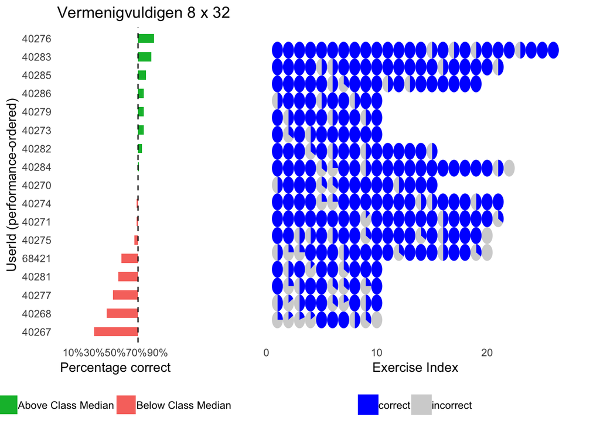

```r
plot_performance_accuracy(tibb = today_data_nested,
                 learning_objective = "Vermenigvuldigen 8 x 32")
```

*How could this help the teacher?*

This visualization of performance accuracy may help the teacher:

### 5.2.2 How did pupils perform in terms of exercise difficulty?

This visualization looks at performance in terms of how exercise difficulty changes during practice. This “small-multiples visualization”" shows exercise difficulty as a function of exercise index (i.e. position of the exercise in time, given learning objective), separately for each pupil. The plots are ordered based on the degree to which difficulty changed from the first to the last exercise in a pupil (top-left panel, largest increase; bottom-right, smallest increase (or even decrease)). Exercise difficulty is adjusted based on performance (making exercises easier after incorrect answers and more difficult after correct answers), meaning that this plot shows learning progress.

```r
plot_performance_difficulty <- function(tibb, learning_objective) {

  # Prepare the data ===========================================================
  difficulty_data_init <-
    tibb %>%
    dplyr::filter(LearningObjective == learning_objective) %>%
    dplyr::select(data) %>%
    tidyr::unnest() %>%
    dplyr::group_by(UserId) %>%
    dplyr::arrange(UserId, SubmitDateTime) %>%
    # ExerciseIx tracks index of the exercise
    dplyr::mutate(ExerciseIx = 1:n())

    difficulty_data_summary <-
      difficulty_data_init %>%
      dplyr::summarize(gain = dplyr::last(Difficulty) - dplyr::first(Difficulty))

    difficulty_data <-
      dplyr::left_join(difficulty_data_init, difficulty_data_summary,
                       by = c("UserId")) %>%
      dplyr::ungroup() %>%
      # Order pupils by gain in difficulty over exercises
      dplyr::mutate(UserId =
                      forcats::fct_drop(
                        forcats::fct_rev(
                          forcats::fct_reorder(difficulty_data_init$UserId, gain)
                          )
                        )
                    )

    # Plot the data ============================================================

    # General design -----------------------------------------------------------
    ggplot2::ggplot(data = difficulty_data,
                mapping = ggplot2::aes(x = ExerciseIx,
                                       y = Difficulty)) +
      ggplot2::facet_wrap("UserId") +

      # Geoms ------------------------------------------------------------------
      ggplot2::geom_line() +
      ggplot2::geom_smooth(method = "loess") +

      # Scales -----------------------------------------------------------------
      ggplot2::scale_x_continuous(name = "Exercise index") +
      ggplot2::scale_y_continuous(name = "Difficulty (a.u.)") +


      ggplot2::labs(title = learning_objective,
                    subtitle = "Change in exercise difficulty as a function practice, ordered by size of change") +

      # Themes -----------------------------------------------------------------
      ggplot2::theme_minimal()
}
```

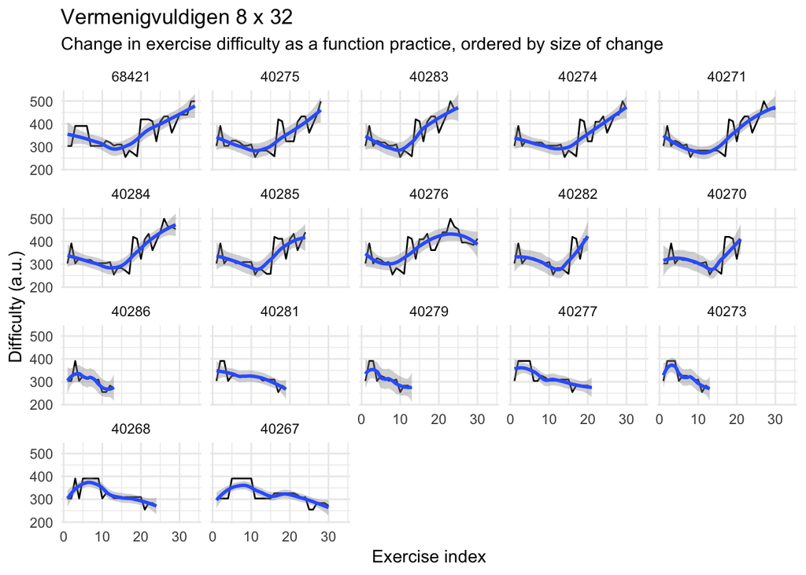

```r
plot_performance_difficulty(tibb = today_data_nested,
                            learning_objective = "Vermenigvuldigen 8 x 32")
```

*How could this help the teacher?*

This visualization of change in exercise difficulty may help the teacher:

- to identify pupils how learned well (increasing trend line) vs pupils who experienced difficulty in performing the exercises (flat or decreasing trend line);
- to estimate whether a small change in difficulty could be related to number of exercises performed (e.g. UserId 40286 perhaps) or failure to understand (small absolute change in difficulty, despite many exercises performed, e.g. UserId 40267);